## Implementação de Balanço Populacional com efeitos de agregação de partículas

**Referência:** Kumar & Ramkrishna 1997-Part III

# A equação do Balanço Populacional

$$ \dfrac{\partial n(l,t)}{\partial t} + \dfrac{\partial}{\partial l}[G(l) n(l,t)] = B - D $$

# Resolução com Técnicas convencionais

e.g: Método das Diferenças Finitas

## Crescimento Puro:

$(B-D) = 0$

Exemplo: $G(l) = 10^3 $

Considere a distribuição inicial de partículas:

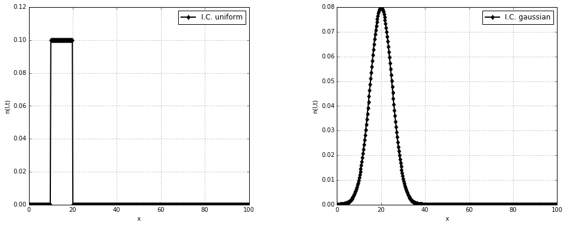

```python
# UNIFORM INITIAL CONDITION
a = 10.0
b = 20.0
Npts = 400
xspan = linspace(0.0, 100.0, Npts)
n0_fnc = lambda v, a, b: 0 if v<a else (1/(b-a) if v<b else 0)
n_t0_uni = empty(Npts)
for i in arange(0, Npts):
    n_t0_uni[i] = n0_fnc(xspan[i], a, b)
mu0_t0 = integrate.trapz(n_t0_uni, xspan)
mu1_t0 = integrate.trapz(n_t0_uni * xspan, xspan)
fig = plt.figure(figsize=(16,6))
plt.subplot(1,2,1)
plt.plot(xspan, n_t0_uni, 'kd-', lw = 2, label='I.C. uniform')
plt.xlabel('x')
plt.ylabel('n(l,t)')
plt.legend()
uniax = fig.gca()

# GAUSSIAN INITIAL CONDITION
mu_ic = 20.0
sigma_ic = 5.0
n0_fnc = lambda v, mu_ic, sigma_ic: 1./(sigma_ic*sqrt(2*pi)) * exp(-1./2.*((v-mu_ic)/sigma_ic)**2)
n_t0_gau = empty(Npts)
for i in arange(0, Npts):
    n_t0_gau[i] = n0_fnc(xspan[i], mu_ic, sigma_ic)
plt.subplot(1,2,2)
plt.plot(xspan, n_t0_gau, 'kd-', lw = 2, label='I.C. gaussian')
plt.xlabel('x')
plt.ylabel('n(l,t)')
plt.legend()
plt.subplots_adjust(wspace = 0.4)
gauax = fig.gca()
# plt.title('MDF Growth and Pure with Npts = ' + str(Npts))
#plotly_fig = tls.mpl_to_plotly( fig )
#plt.show()
#py.iplot(plotly_fig, filename = 'basic-line')
```

Utilizando o método das diferenças finitas com aproximação *Backward*:

```
N(t_2) / N(t_0) = 1.0000000000000002
M(t_2) / M(t_0) = 1.5364705882352936
N(t_2) / N(t_0) = 0.9974677021490498
M(t_2) / M(t_0) = 1.8729380939621945
```

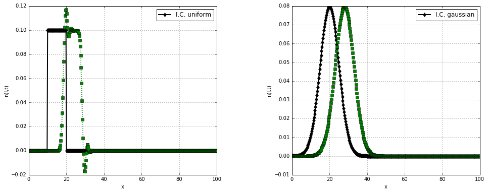

```python
arg1 = {}
arg1['Npts'] = Npts
arg1['delta'] = xspan[1]-xspan[0]
arg1['x'] = xspan
growth_fnc = lambda xi: 1e3
arg1['growth_fnc'] = growth_fnc
diff_growth_fnc = lambda xi: 0.0
arg1['diff_growth_fnc'] = diff_growth_fnc
t_END = 8e-3
t_INTERM = t_END/2.0
tspan = array([0.0, t_INTERM, t_END])

# UNIFORM CASE
y0 = n_t0_uni
try:
    ySIM = caller_ode_MDF_growPure(y0, arg1, tspan)
except:
    print('Error NDF growPure uniform')
    ySIM = zeros([tspan.shape[0], arg1['Npts']])

k_t2 = where(tspan >= t_END)[0][0]
plotmdfUni, = uniax.plot(xspan, ySIM[k_t2,:], 'gs:', lw = 2, label='$t_2=${} uniform'.format(t_END))
mu0_t2 = integrate.trapz(ySIM[k_t2,:], xspan)
mu1_t2 = integrate.trapz(ySIM[k_t2,:]*xspan, xspan)
print('N(t_2) / N(t_0) = {}'.format(mu0_t2/mu0_t0))
print('M(t_2) / M(t_0) = {}'.format(mu1_t2/mu1_t0))

# GAUSS CASE
y0 = n_t0_gau
try:
    ySIM = caller_ode_MDF_growPure(y0, arg1, tspan)
except:
    print('Error MDF growPure gaussian')
    ySIM = zeros([tspan.shape[0], arg1['Npts']])

k_t2 = where(tspan >= t_END)[0][0]
plotmdfGau, = gauax.plot(xspan, ySIM[k_t2,:], 'gs:', lw = 2, label='$t_2=${} gaussian'.format(t_END))
mu0_t2 = integrate.trapz(ySIM[k_t2,:], xspan)
mu1_t2 = integrate.trapz(ySIM[k_t2,:]*xspan, xspan)
print('N(t_2) / N(t_0) = {}'.format(mu0_t2/mu0_t0))
print('M(t_2) / M(t_0) = {}'.format(mu1_t2/mu1_t0))

fig
```

# Crescimento com Nucleação

$$ B - D = B_0 \delta (l-l_{min}) dl$$$$ B_0 = 10^1 $$

```
N(t_2) / N(t_0) = 1.0880239521489803
M(t_2) / M(t_0) = 1.898253949006104
N(t_2) / N(t_0) = 1.0880239521489803
M(t_2) / M(t_0) = 1.898253949006104
```

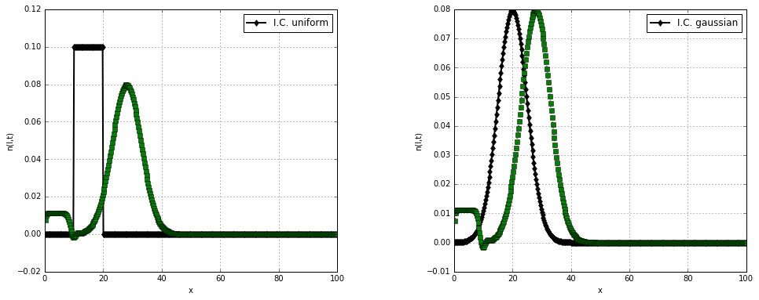

```python
plotmdfUni.remove()
plotmdfGau.remove()
arg1['nucl_fnc'] = lambda v: 1e1

# UNIFORM CASE
ySIM = caller_ode_MDF_growNucl(y0, arg1, tspan)

k_t2 = where(tspan >= t_END)[0][0]
plotmdfUniNucl, = uniax.plot(xspan, ySIM[k_t2,:], 'gs:', lw = 2, label='$t_2=${} uniform'.format(t_END))
mu0_t2 = integrate.trapz(ySIM[k_t2,:], xspan)
mu1_t2 = integrate.trapz(ySIM[k_t2,:]*xspan, xspan)
print('N(t_2) / N(t_0) = {}'.format(mu0_t2/mu0_t0))
print('M(t_2) / M(t_0) = {}'.format(mu1_t2/mu1_t0))

# GAUSS CASE
y0 = n_t0_gau
ySIM = caller_ode_MDF_growNucl(y0, arg1, tspan)

k_t2 = where(tspan >= t_END)[0][0]
plotmdfGauNucl, = gauax.plot(xspan, ySIM[k_t2,:], 'gs:', lw = 2, label='$t_2=${} gaussian'.format(t_END))
mu0_t2 = integrate.trapz(ySIM[k_t2,:], xspan)
mu1_t2 = integrate.trapz(ySIM[k_t2,:]*xspan, xspan)
print('N(t_2) / N(t_0) = {}'.format(mu0_t2/mu0_t0))
print('M(t_2) / M(t_0) = {}'.format(mu1_t2/mu1_t0))

fig
```

## Aplicação do Método de Kumar & Ramkrishina 1997 - Part III

# O método: *Moving Sectional Method*

- **Combinação de método de discretização (Método das Classes) com o Método das Características:**
  - suprime dificuldades de difusividade numérica e estabilidade de técnicas anteriores
  - técnica genérica aplicável em diferentes casos
- **Aplicável para um *grid* arbitrário, permitindo controle da resolução e eficiência computacional**
- **Aplicável para processos particulados com mecanismos de:**
  - Nucleação
  - Crescimento
  - Dissolução
  - Agregação

**VANTAGEM:** A capacidade de acompanhar com rigor a presença das **descontinuidades móveis** (devido ao crescimento de partículas)

**DESVANTAGEM:** Para incluir a nucleação requer adições sucessivas de novas seções (*bins*)

Sistema de Equação Diferencial Ordinária com Nucleação, Crescimento e Agregação de Partículas via método *Moving Sectional Method* (**MSM**):

$$ \underset{\text{Acúmulo de partículas por Bin}}{\dfrac{dN_i(t)}{dt}} = \underset{\text{Termo de agregação}}{R_{agg}} + \underset{\text{Termo de nucleação}}{\int_{v_i(t)}^{v_{i+1}(t)} S(v) dv} $$$$ \dfrac{dx_i}{dt} = G(x_i) $$$$ R_{agg} = \sum_{\underset{x_{i-1}(t) \leq \nu(t) \leq x_{i+1}(t)}{j,k}}^{i \leq j\leq k} [(1-\frac{1}{2} \delta_{j,k})\eta q_{j,k} N_j(t)N_k(t)] - N_i(t)\sum_{k=1}^{M}q_{i,k}N_k(t) $$

$$ \eta = \begin{cases} \dfrac{x_{i+1}(t) - \nu}{x_{i+1}(t)-x_i(t)}\text{, } x_i(t) \leq \nu \leq x_{i+1}(t) \\ \dfrac{x_{i-1}(t) - \nu}{x_{i-1}(t)-x_i(t)}\text{, } x_{i-1}(t) \leq \nu \leq x_{i}(t) \end{cases}$$$$ \nu(t) = x_j(t)+x_k(t)$$

## Crescimento e Nucleacão com M.S.M.

$S(l) = B_0\delta(l-l_{min}) \rightarrow B_0 = 10$

$G(x) = 10^3$

$q(x_j,x_k) = 0$

```
N(t_2) / N(t_0) = 1.0799999999999998
M(t_2) / M(t_0) = 1.5548888888888872
N(t_2) / N(t_0) = 1.0800025337795944
M(t_2) / M(t_0) = 1.416152217398835
```

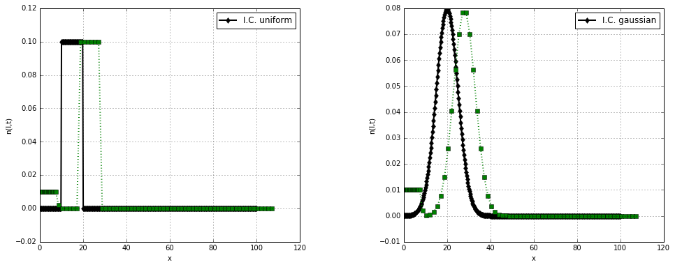

```python
plotmdfUniNucl.remove()
plotmdfGauNucl.remove()

Npts = 60
lspan = linspace(0.0, 100.0, Npts + 1)
xspan = (lspan[1:] + lspan[0:-1]) * 1/2.0
arg1 = {}
arg1['Npts'] = Npts
arg1['lspan'] = lspan
arg1['growth_fnc'] = growth_fnc
arg1['nucl_fnc'] = lambda: 1e1
arg1['aggre_func'] = lambda xj, xk: 0.0
tspan = linspace(0.0, t_END, 21)

# UNIFORM CASE
n0_fnc = lambda v, a, b: 0 if v<a else (1/(b-a) if v<b else 0)
N_t0 = empty(Npts)
n_t0_num = empty_like(N_t0)
for i in arange(0, Npts):
    y, err = \
    integrate.quad(n0_fnc, lspan[i], lspan[i+1], args=(a,b))
    N_t0[i] = y
    n_t0_num[i] = N_t0[i] / (lspan[i+1] - lspan[i])
mu0_t0 = sum(N_t0)
mu1_t0 = sum(N_t0 * xspan)
y0 = hstack((xspan, N_t0))
d = caller_ode_MovingSectional_AggreGrowNucl(y0, arg1, tspan)

k_t2 = where(tspan >= t_END)[0][0]
uniax.plot(d['x'][k_t2], d['n_num'][k_t2], 'gs:', lw = 2, label='$t_2=${} M.S.M.'.format(t_END))
mu0_t2 = sum(d['N'][k_t2])
print('N(t_2) / N(t_0) = {}'.format(mu0_t2/mu0_t0))
mu1_t2 = sum(d['N'][k_t2] * d['x'][k_t2])
print('M(t_2) / M(t_0) = {}'.format(mu1_t2/mu1_t0))

# GAUSSIAN CASE
arg1['Npts'] = Npts
n0_fnc = lambda v, mu_ic, sigma_ic: 1./(sigma_ic*sqrt(2*pi)) * exp(-1./2.*((v-mu_ic)/sigma_ic)**2)
N_t0 = empty(Npts)
n_t0_num = empty_like(N_t0)
for i in arange(0, Npts):
    y, err = \
    integrate.quad(n0_fnc, lspan[i], lspan[i+1], args=(mu_ic,sigma_ic))
    N_t0[i] = y
    n_t0_num[i] = N_t0[i] / (lspan[i+1] - lspan[i])
mu0_t0 = sum(N_t0)
mu1_t0 = sum(N_t0 * xspan)
y0 = hstack((xspan, N_t0))
d = caller_ode_MovingSectional_AggreGrowNucl(y0, arg1, tspan)

k_t2 = where(tspan >= t_END)[0][0]
gauax.plot(d['x'][k_t2], d['n_num'][k_t2], 'gs:', lw = 2, label='$t_2=${} M.S.M.'.format(t_END))
mu0_t2 = sum(d['N'][k_t2])
print('N(t_2) / N(t_0) = {}'.format(mu0_t2/mu0_t0))
mu1_t2 = sum(d['N'][k_t2] * d['x'][k_t2])
print('M(t_2) / M(t_0) = {}'.format(mu1_t2/mu1_t0))

fig
```

Agregação de Partículas com **MSM**

$S(l) = 0.0$

$G(x) = 0.0$

$q(x_j,x_k) = 50.0$

```
N(t_2) / N(t_0) = 0.8333333606758849
M(t_2) / M(t_0) = 0.999986451462126
```

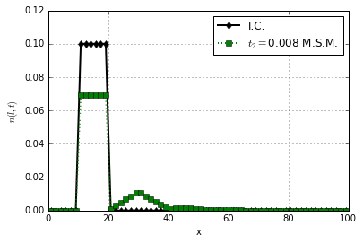

```python
# UNIFORM CASE
fig_aggr = plt.figure()
n0_fnc = lambda v, a, b: 0 if v<a else (1/(b-a) if v<b else 0)
N_t0 = empty(Npts)
n_t0_num = empty_like(N_t0)
for i in arange(0, Npts):
    y, err = \
    integrate.quad(n0_fnc, lspan[i], lspan[i+1], args=(a,b))
    N_t0[i] = y
    n_t0_num[i] = N_t0[i] / (lspan[i+1] - lspan[i])
mu0_t0 = sum(N_t0)
mu1_t0 = sum(N_t0 * xspan)
fig_aggr.gca().plot(xspan, n_t0_num, 'kd-', lw = 2, label='I.C.')
plt.xlabel('x')
plt.ylabel('$n(l,t)$')

arg1 = {}
arg1['Npts'] = Npts
arg1['lspan'] = lspan
arg1['growth_fnc'] = lambda v: 0.0
arg1['nucl_fnc'] = lambda: 0.0
arg1['aggre_func'] = lambda xj, xk: 50.0
t_END = 8e-3
tspan = linspace(0.0, t_END, 11)
y0 = hstack((xspan, N_t0))
d = caller_ode_MovingSectional_AggreGrowNucl(y0, arg1, tspan)

k_t2 = where(tspan >= t_END)[0][0]
fig_aggr.gca().plot(d['x'][k_t2], d['n_num'][k_t2], 'gs:', lw = 2, label='$t_2=${} M.S.M.'.format(t_END))
mu0_t2 = sum(d['N'][k_t2])
print('N(t_2) / N(t_0) = {}'.format(mu0_t2/mu0_t0))
mu1_t2 = sum(d['N'][k_t2] * d['x'][k_t2])
print('M(t_2) / M(t_0) = {}'.format(mu1_t2/mu1_t0))
plt.legend();
```

Agregação de Partículas com **MSM**

$S(l) = 0.0$

$G(x) = 1e3$

$q(x_j,x_k) = 50.0$

```
N(t_2) / N(t_0) = 0.8333333329433059
M(t_2) / M(t_0) = 1.4860740781535449
```

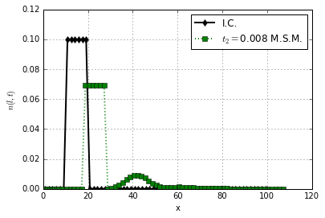

```python
# UNIFORM CASE
fig_aggr = plt.figure()
n0_fnc = lambda v, a, b: 0 if v<a else (1/(b-a) if v<b else 0)
N_t0 = empty(Npts)
n_t0_num = empty_like(N_t0)
for i in arange(0, Npts):
    y, err = \
    integrate.quad(n0_fnc, lspan[i], lspan[i+1], args=(a,b))
    N_t0[i] = y
    n_t0_num[i] = N_t0[i] / (lspan[i+1] - lspan[i])
mu0_t0 = sum(N_t0)
mu1_t0 = sum(N_t0 * xspan)
fig_aggr.gca().plot(xspan, n_t0_num, 'kd-', lw = 2, label='I.C.')
plt.xlabel('x')
plt.ylabel('$n(l,t)$')

arg1 = {}
arg1['Npts'] = Npts
arg1['lspan'] = lspan
arg1['growth_fnc'] = lambda v: 1e3
arg1['nucl_fnc'] = lambda: 0.0
arg1['aggre_func'] = lambda xj, xk: 50.0
t_END = 8e-3
tspan = linspace(0.0, t_END, 11)
y0 = hstack((xspan, N_t0))
d = caller_ode_MovingSectional_AggreGrowNucl(y0, arg1, tspan)

k_t2 = where(tspan >= t_END)[0][0]
fig_aggr.gca().plot(d['x'][k_t2], d['n_num'][k_t2], 'gs:', lw = 2, label='$t_2=${} M.S.M.'.format(t_END))
mu0_t2 = sum(d['N'][k_t2])
print('N(t_2) / N(t_0) = {}'.format(mu0_t2/mu0_t0))
mu1_t2 = sum(d['N'][k_t2] * d['x'][k_t2])
print('M(t_2) / M(t_0) = {}'.format(mu1_t2/mu1_t0))
plt.legend();
```

Agregação de Partículas com **MSM**

$S(l) = B_0\delta(l-l_{min}) \rightarrow B_0 = 10$

$G(x)=10^3$

$q(xj,xk)=50.0$

```
N(t_2) / N(t_0) = 0.9006938247373591
M(t_2) / M(t_0) = 1.5055564703061868
```

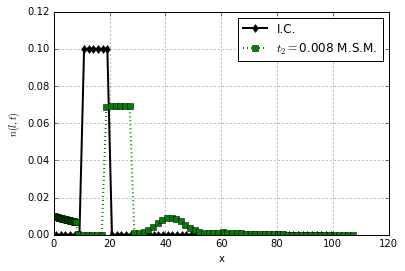

```python
# UNIFORM CASE
fig_aggr = plt.figure()
n0_fnc = lambda v, a, b: 0 if v<a else (1/(b-a) if v<b else 0)
N_t0 = empty(Npts)
n_t0_num = empty_like(N_t0)
for i in arange(0, Npts):
    y, err = \
    integrate.quad(n0_fnc, lspan[i], lspan[i+1], args=(a,b))
    N_t0[i] = y
    n_t0_num[i] = N_t0[i] / (lspan[i+1] - lspan[i])
mu0_t0 = sum(N_t0)
mu1_t0 = sum(N_t0 * xspan)
fig_aggr.gca().plot(xspan, n_t0_num, 'kd-', lw = 2, label='I.C.')
plt.xlabel('x')
plt.ylabel('$n(l,t)$')

arg1 = {}
arg1['Npts'] = Npts
arg1['lspan'] = lspan
arg1['growth_fnc'] = lambda v: 1e3
arg1['nucl_fnc'] = lambda: 1e1
arg1['aggre_func'] = lambda xj, xk: 50.0
t_END = 8e-3
tspan = linspace(0.0, t_END, 51)
y0 = hstack((xspan, N_t0))
d = caller_ode_MovingSectional_AggreGrowNucl(y0, arg1, tspan)

k_t2 = where(tspan >= t_END)[0][0]
fig_aggr.gca().plot(d['x'][k_t2], d['n_num'][k_t2], 'gs:', lw = 2, label='$t_2=${} M.S.M.'.format(t_END))
mu0_t2 = sum(d['N'][k_t2])
print('N(t_2) / N(t_0) = {}'.format(mu0_t2/mu0_t0))
mu1_t2 = sum(d['N'][k_t2] * d['x'][k_t2])
print('M(t_2) / M(t_0) = {}'.format(mu1_t2/mu1_t0))
plt.legend();
```